# Exploring Bike Share Data: Visualizing the effects of a global pandemic on San Francisco Bay Area's bike share system

## by Maren Zoller

## Investigation Overview

In this investigation, I wanted to look at the features influencing bike trip duration in a dataset of bike share data from San Francisco Bay Area's Bay Wheels (formerly Ford GoBike) bike share system. The main focus was on the attributes month, weekday, time of day, and user type. Within the investigation I compared their influence on bike trip duration for the first half year of 2019 and 2020.

## Dataset Overview

The data consisted of information on 2,530,524 individual bike trips taken between January 2019 and June 2019 and January 2020 and June 2020, such as start and end station location, start and end date and time of the trip, user type, station name, and bike type. To enrich the investigation I used the trip start time to extract month, weekday and hour of the trip, and the latitude and longitude data to add a start city and end city feature to the dataset. Later, I transformed duration seconds to duration minutes, to simplify the trip duration analysis. Also, I performed several cleaning steps to change datatypes and deal with missing data and outliers. All wrangling steps are documented in detail in the exploration notebook.

## Distribution of bike trip durations

Bike trip durations in the dataset take on a very large range of values, from a few seconds to about a day. Plotted on a logarithmic scale and limited to the first 100 minutes, the distributions of duration minutes are unimodal and heavily right-skewed. In 2020, the number of trips with a duration over 20 minutes is higher than in 2019.

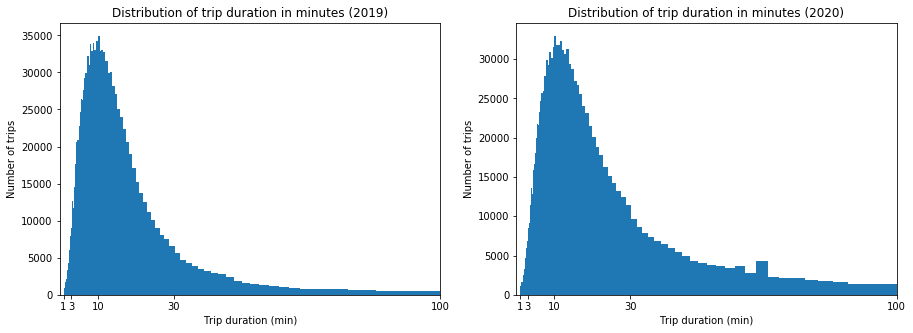

```python
# log scale
log_binsize = 0.02
bins_19 = 10 ** np.arange(0, np.log10(visualize_19['duration_min'].max())+log_binsize, log_binsize)
bins_20 = 10 ** np.arange(0, np.log10(visualize_20['duration_min'].max())+log_binsize, log_binsize)

plt.figure(figsize = [15, 5])
# 2019 distribution
plt.subplot(1, 2, 1) # 1 row, 2 cols, subplot 1
ticks =  [1 , 3, 10, 30, 100, 300]
labels = ['{}'.format(v) for v in ticks]
plt.hist(data = visualize_19, x = 'duration_min', bins = bins_19)
plt.xticks(ticks, labels)
plt.xlabel('Trip duration (min)')
plt.ylabel('Number of trips')
plt.title('Distribution of trip duration in minutes (2019)')
plt.xlim(0,100)
# 2020 distribution
plt.subplot(1, 2, 2) # 1 row, 2 cols, subplot 2
ticks = [1 , 3, 10, 30, 100, 300]
labels = ['{}'.format(v) for v in ticks]
plt.hist(data = visualize_20, x = 'duration_min', bins = bins_20)
plt.xlabel('Trip duration (min)')
plt.ylabel('Number of trips')
plt.xticks(ticks, labels)
plt.title('Distribution of trip duration in minutes (2020)')
plt.xlim(0,100)
plt.show();
```

## Number of bike trips per month

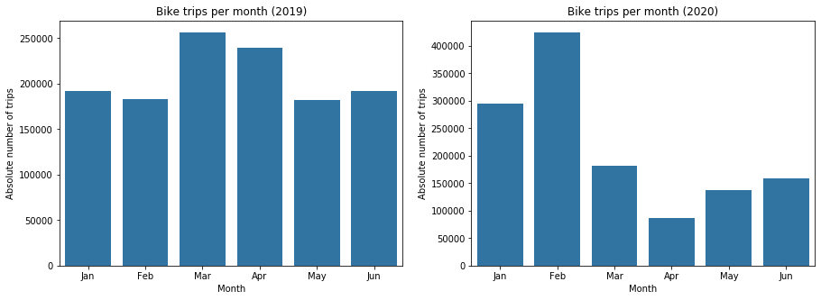

```python
plt.figure(figsize = [15, 5])

# 2019 absolute numbers
plt.subplot(1, 2, 1) # 1 row, 2 cols, subplot 1
# create the plot
base_color = sb.color_palette()[0]
sb.countplot(data = visualize_19, x = 'month', color = base_color)
plt.xlabel('Month')
plt.ylabel('Absolute number of trips')
plt.title('Bike trips per month (2019)')

# 2020 absolute numbers
plt.subplot(1, 2, 2) # 1 row, 2 cols, subplot 2
# create the plot
base_color = sb.color_palette()[0]
sb.countplot(data = visualize_20, x = 'month', color = base_color)
plt.xlabel('Month')
plt.ylabel('Absolute number of trips')
plt.title('Bike trips per month (2020)');
```

## Proportion of bike trips per user type

In 2019, the majority of bike trips is taken by Bay Wheels subscribers (85%). Subscribers pay a monthly or annual fee to use the bike share system, as opposed to customers, that pay per trip and are charged based on trip duration.

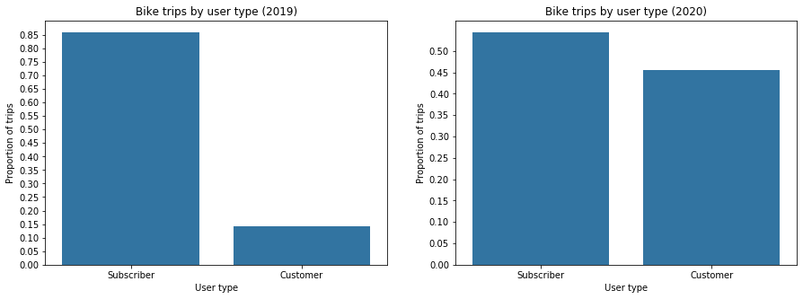

```python
n_points_19 = visualize_19.shape[0]
max_count_19 = visualize_19['user_type'].value_counts().max()
max_prop_19 = max_count_19 / n_points_19
# generate tick mark locations and names
tick_props_19 = np.arange(0, max_prop_19, 0.05)
tick_names_19 = ['{:0.2f}'.format(v) for v in tick_props_19]

n_points_20 = visualize_20.shape[0]
max_count_20 = visualize_20['user_type'].value_counts().max()
max_prop_20 = max_count_20 / n_points_20
# generate tick mark locations and names
tick_props_20 = np.arange(0, max_prop_20, 0.05)
tick_names_20 = ['{:0.2f}'.format(v) for v in tick_props_20]

plt.figure(figsize = [15, 5])
# 2019 distribution
plt.subplot(1, 2, 1) # 1 row, 2 cols, subplot 1
# create the plot
base_color = sb.color_palette()[0]
sb.countplot(data = visualize_19, x = 'user_type', color = base_color)
plt.yticks(tick_props_19 * n_points_19, tick_names_19)
plt.xlabel('User type')
plt.ylabel('Proportion of trips')
plt.title('Bike trips by user type (2019)')

plt.subplot(1, 2, 2) # 1 row, 2 cols, subplot 2
# create the plot
base_color = sb.color_palette()[0]
sb.countplot(data = visualize_20, x = 'user_type', color = base_color)
plt.yticks(tick_props_20 * n_points_20, tick_names_20)
plt.xlabel('User type')
plt.ylabel('Proportion of trips')
plt.title('Bike trips by user type (2020)');
```

## Number of bike trips by user type per month

The distribution of bike trips per user type changed significantly from 2019 to 2020. Can this be tied to the lockdown measures as well? The visualization of bike trips by user type and month does not entirely confirm this.

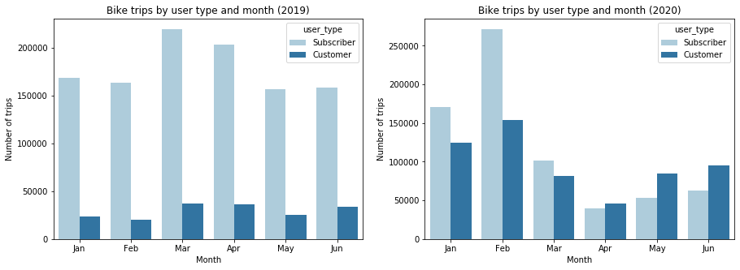

```python
plt.figure(figsize = [15, 5]) # larger figure size for subplots
# 2019 distribution
plt.subplot(1, 2, 1) # 1 row, 2 cols, subplot 1
# create the plot
sb.countplot(data = visualize_19, x = 'month', hue='user_type', palette='Paired')
plt.ylabel('Number of trips')
plt.xlabel('Month')
plt.title('Bike trips by user type and month (2019)')

plt.subplot(1, 2, 2) # 1 row, 2 cols, subplot 2
# create the plot
sb.countplot(data = visualize_20, x = 'month', hue='user_type', palette='Paired')
plt.ylabel('Number of trips')
plt.xlabel('Month')
plt.title('Bike trips by user type and month (2020)');
```

## Bike trip duration by month

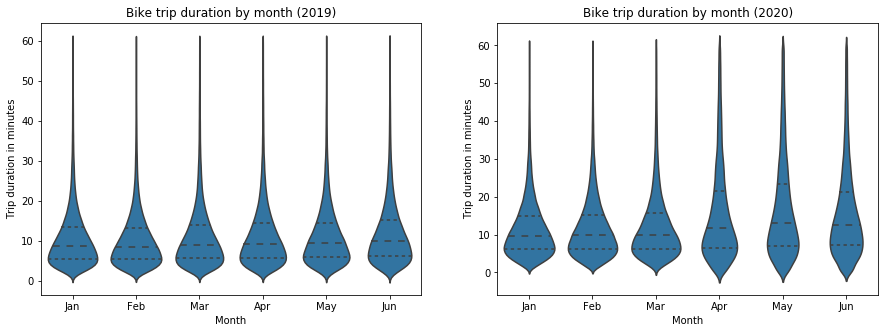

```python
# creating duration snapshots
duration_snapshot_19 = visualize_19.query('duration_min < 60')
duration_snapshot_20 = visualize_20.query('duration_min < 60')

# plotting bike trip duration by month
plt.figure(figsize = [15, 5])
# 2019 distribution
plt.subplot(1, 2, 1) # 1 row, 2 cols, subplot 1
# create the plot
base_color = sb.color_palette()[0]
sb.violinplot(data = duration_snapshot_19, x = 'month', y = 'duration_min', color = base_color,
              inner = 'quartile')
plt.title('Bike trip duration by month (2019)')
plt.xlabel('Month')
plt.ylabel('Trip duration in minutes')

plt.subplot(1, 2, 2) # 1 row, 2 cols, subplot 2
# create the plot
base_color = sb.color_palette()[0]
sb.violinplot(data = duration_snapshot_20, x = 'month', y = 'duration_min', color = base_color,
              inner = 'quartile')
plt.title('Bike trip duration by month (2020)')
plt.xlabel('Month')
plt.ylabel('Trip duration in minutes');
```

## Bike trip duration by day of the week

In 2019, there is an observable difference between weekday and weekend trip duration. This is most visible beyond the median (weekdays: ca. 9 minutes, weekends: ca. 11 minutes) and especially the third quartile (weekdays: ca. 13, weekends: ca. 17 minutes).

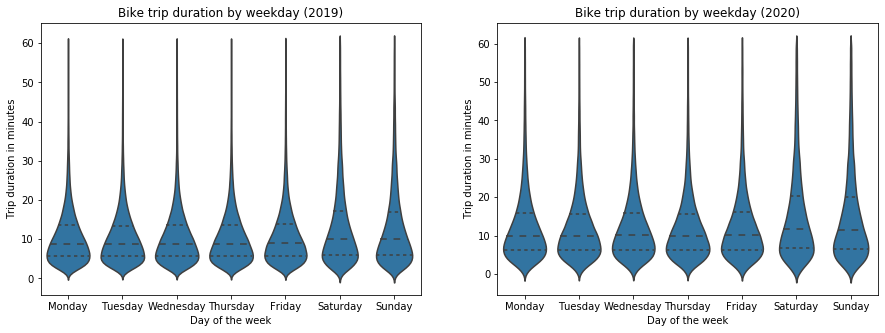

```python
# plotting bike trip duration by day of the week
plt.figure(figsize = [15, 5])
# 2019 distribution
plt.subplot(1, 2, 1) # 1 row, 2 cols, subplot 1
# create the plot
base_color = sb.color_palette()[0]
sb.violinplot(data = duration_snapshot_19, x = 'week_day', y = 'duration_min', color = base_color,
              inner = 'quartile')
plt.title('Bike trip duration by weekday (2019)')
plt.xlabel('Day of the week')
plt.ylabel('Trip duration in minutes')

plt.subplot(1, 2, 2) # 1 row, 2 cols, subplot 2
# create the plot
base_color = sb.color_palette()[0]
sb.violinplot(data = duration_snapshot_20, x = 'week_day', y = 'duration_min', color = base_color,
              inner = 'quartile')
plt.title('Bike trip duration by weekday (2020)')
plt.xlabel('Day of the week')
plt.ylabel('Trip duration in minutes');
```

## Bike trip duration by time of day

To visualize bike trip duration by time of day, I decided against violin plots, but used a categorical representation using duration intervals instead. This allows for visualizing all trips, not only the previously chosen duration snapshot.

In 2019, there are very little trips between 11pm and 5 am, trips by hours of the day has a bimodal distribution with one peak at 8am and another, slightly higher one at 5pm. Bike trips up to 10 minutes of length follow the 8am and 5m peaks, with an additional smaller peak at 12pm. Bike trips above 30 minutes of length follow a left-skewed distribution, with a 5pm peak.

In 2020, the two peaks in the distribution are still visible, but the 5pm one is a lot more prominent than the 8 am one. I assume, that 5pm combines a high number of commuter trips with a similarly high number of recreational bike trips. The proportion of longer trips in relation to trips shorter than 20 minutes has increased. Judging from the visualization, Bay Wheels bikes are largely used for commuting to and from work, and following the lockdown measures shorter commuting trips decreased and recreational longer trips increased.

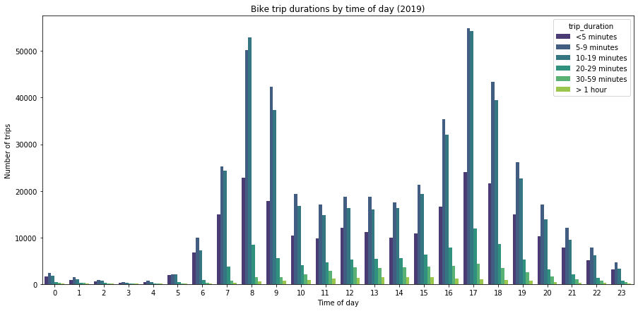

```python
# 2019 trip duration by time of day
plt.figure(figsize = [15, 7])
sb.countplot(data = visualize_19, x = 'hour', hue='trip_duration', palette='viridis')
plt.xlabel('Time of day')
plt.ylabel('Number of trips')
plt.title('Bike trip durations by time of day (2019)');
```

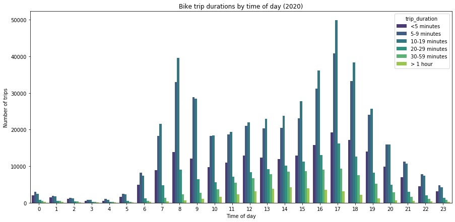

```python
# 2020 trip duration by time of day
plt.figure(figsize = [15, 7])
sb.countplot(data = visualize_20, x = 'hour', hue='trip_duration', palette='viridis')
plt.xlabel('Time of day')
plt.ylabel('Number of trips')
plt.title('Bike trip durations by time of day (2020)');
```

## Bike trip duration by user type

In 2020, an interesting change in distributions can be observed. The subscriber curve stays nearly the same, but shows an increase in trips above 20 minutes and an increased median trip duration. The customer distribution now resembles the subscriber one, with a lower median trip duration than in 2019 caused by an extreme increase in shorter trips below 20 minutes. The number of customer trips increased in all categories, also the longer trips, but no category shows a greater increase than the one below 5 minutes. While I can not prove this with the data at hand, I suspect the overall increase in customer trips to be related to Bay area residents looking for social-distance friendly recreational activities, and the increase in trips shorter than 5 minutes with first-time customers testing out if Bay Wheels works for them.

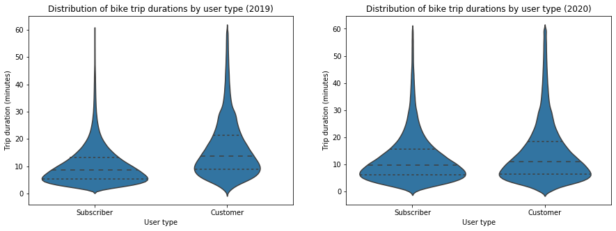

```python
plt.figure(figsize = [15, 5]) # larger figure size for subplots
# 2019 distribution
plt.subplot(1, 2, 1) # 1 row, 2 cols, subplot 1
# create the plot
base_color = sb.color_palette()[0]
sb.violinplot(data = duration_snapshot_19, x = 'user_type', y='duration_min', color=base_color, inner='quartile')
plt.ylabel('Trip duration (minutes)')
plt.xlabel('User type')
plt.title('Distribution of bike trip durations by user type (2019)')

plt.subplot(1, 2, 2) # 1 row, 2 cols, subplot 2
# create the plot
sb.violinplot(data = duration_snapshot_20, x = 'user_type', y='duration_min', color=base_color, inner='quartile')
plt.ylabel('Trip duration (minutes)')
plt.xlabel('User type')
plt.title('Distribution of bike trip durations by user type (2020)');
```

## Bike trip duration by user type and month

As previously seen, number of bike trips by user type and month had largely different distributions in 2019 and 2020. Is this difference also visible in bike trip duration? To investigate this question, average bike trip duration by month and user type are visualized in a bar chart, with error bars representing variability.

In 2019, mean subscriber trip duration is at a similar level across all investigated months, increasing from ca. 10 to ca. 11 minutes from January to June. Customer trips are on average about 15 minutes longer, and have a higher trip duration variability. Average trip duration is longest in March.

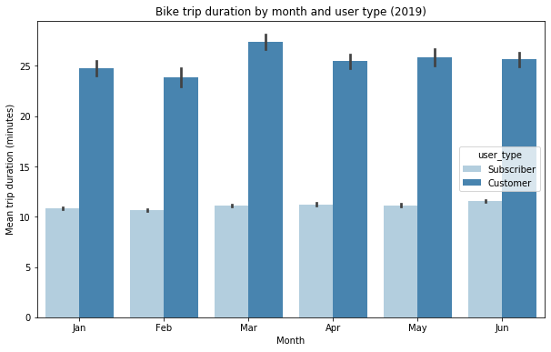

```python
plt.figure(figsize = [10, 6])
# 2019 distribution
sb.barplot(data = visualize_19, x = 'month', y = 'duration_min', hue='user_type', palette='Blues')
plt.ylabel('Mean trip duration (minutes)')
plt.xlabel('Month')
plt.title('Bike trip duration by month and user type (2019)');
```

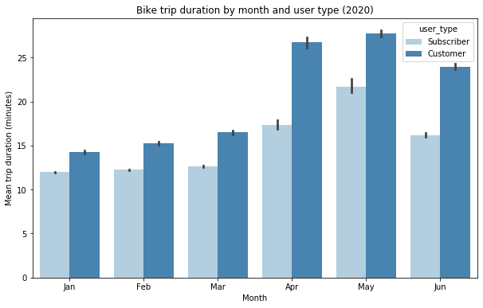

```python
plt.figure(figsize = [10, 6])
# 2020 distribution
sb.barplot(data = visualize_20, x = 'month', y = 'duration_min', hue='user_type', palette='Blues')
plt.ylabel('Mean trip duration (minutes)')
plt.xlabel('Month')
plt.title('Bike trip duration by month and user type (2020)');
```

## Bike trip duration by start station location

The previous visualizations showed the impact of user type, month, week day and hour of the day on bike trip duration in 2019 and 2020. To close the presentation, I am using a map visualization of trips up to 60 minutes length to compare the trip duration per station in 2019 and 2020. This visualization confirms, that the change in trip duration from 2019 to 2020 is not a regional phenomenon, but visible in all 3 regions offering Bay Wheels bikes. In 2019, the majority of trip duration markers is violet or blue, representing trips below 20 minutes. There are less turquoise and green markers (trip length above 30 minutes) to be found, most of them at the outskirts of the three cities. For 2020, there are a lot more green and even some yellow markers visible. The start stations for these longer trips are both found at outskirts and city centers.

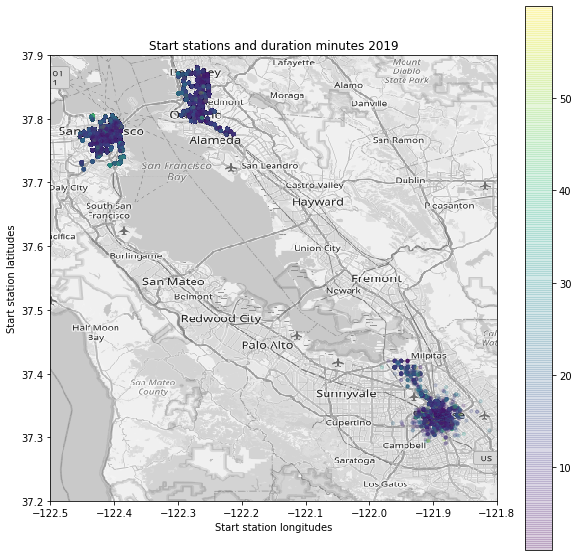

```python
map_edges_19 = (-122.5,-121.8,37.2,37.9)
map_image_19 = plt.imread('bay_area_map_bw.png')
cm = plt.cm.get_cmap('viridis')
fig, ax = plt.subplots(figsize = (10,10))
sc = ax.scatter(duration_snapshot_19.start_station_longitude, duration_snapshot_19.start_station_latitude, zorder=1, alpha= 0.2, c=duration_snapshot_19.duration_min, s=10, cmap=cm)
plt.colorbar(sc)
ax.set_xlim(map_edges_19[0],map_edges_19[1])
ax.set_ylim(map_edges_19[2],map_edges_19[3])
ax.set_title('Start stations and duration minutes 2019')
ax.set_xlabel('Start station longitudes')
ax.set_ylabel('Start station latitudes')
ax.imshow(map_image_19, zorder=0, extent = map_edges_19, aspect= 'equal')
plt.show();
```

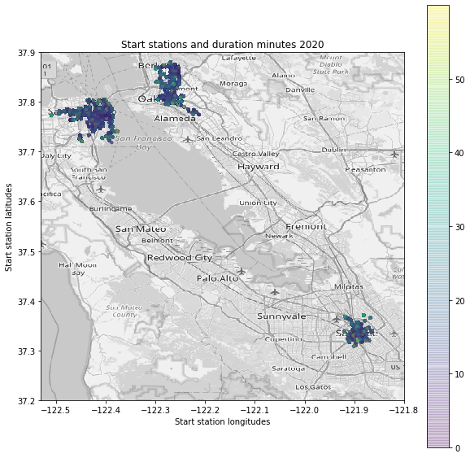

```python
map_edges_20 = (-122.53,-121.8,37.2,37.9)
map_image_20 = plt.imread('bay_area_map_bw.png')
cm = plt.cm.get_cmap('viridis')
fig, ax = plt.subplots(figsize = (10,10))
sc = ax.scatter(duration_snapshot_20.start_long, duration_snapshot_20.start_lat, zorder=1, alpha= 0.2, c=duration_snapshot_20.duration_min, s=10, cmap=cm)
plt.colorbar(sc)
ax.set_xlim(map_edges_20[0],map_edges_20[1])
ax.set_ylim(map_edges_20[2],map_edges_20[3])
ax.set_title('Start stations and duration minutes 2020')
ax.set_xlabel('Start station longitudes')
ax.set_ylabel('Start station latitudes')
ax.imshow(map_image_20, zorder=0, extent = map_edges_20, aspect= 'equal')
plt.show();
```

```python
! jupyter nbconvert Exploring_Bike_Share_Data_Slides.ipynb --to slides --post serve --template output_toggle
```